# Logistic Regression vs Gradient Boosting

# 1.5.2 Factor Variables

```r
summ.factor <- data.frame(summary(select(loans_tr,c("NAME_TYPE_SUITE","FLAG_OWN_CAR",
                        "FLAG_OWN_REALTY","CODE_GENDER","NAME_CONTRACT_TYPE")))) %>%
  filter(Freq!='NA') %>%
  select(Var2,Freq)
  kable(summ.factor,col.names = c("Varible Name","Frequency"),"html",caption ="Factor Varible frequency -Loans Dataset") %>%
  kable_styling(bootstrap_options = "striped","hover",full_width = F, position = "left")
```

Factor Varible frequency -Loans Dataset

| Varible Name | Frequency |
| --- | --- |
| NAME_TYPE_SUITE | Unaccompanied :248526 |
| NAME_TYPE_SUITE | Family : 40149 |
| NAME_TYPE_SUITE | Spouse, partner: 11370 |
| NAME_TYPE_SUITE | Children : 3267 |
| NAME_TYPE_SUITE | Other_B : 1770 |
| NAME_TYPE_SUITE | : 1292 |
| NAME_TYPE_SUITE | (Other) : 1137 |
| FLAG_OWN_CAR | N:202924 |
| FLAG_OWN_CAR | Y:104587 |
| FLAG_OWN_REALTY | N: 94199 |
| FLAG_OWN_REALTY | Y:213312 |
| CODE_GENDER | F :202448 |
| CODE_GENDER | M :105059 |
| CODE_GENDER | XNA: 4 |
| NAME_CONTRACT_TYPE | Cash loans :278232 |
| NAME_CONTRACT_TYPE | Revolving loans: 29279 |

# 1.5.3 Here we look at some Histograms

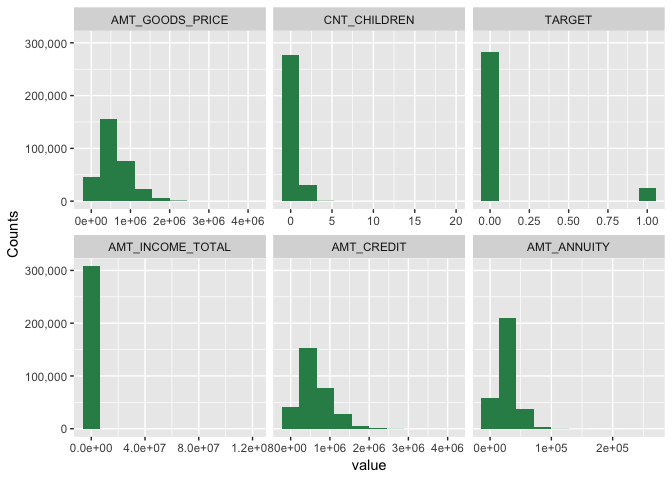

```r
# Create a Long dataset from loans_tr

loans_tr.melt <- melt(loans_tr[,sapply(loans_tr,is.numeric)],id.vars=c("SK_ID_CURR"))

## Using Melt to histogram with 10 bins
ggplot(loans_tr.melt,aes(x=value,..count..),na.rm=TRUE)+
  facet_wrap(~variable,scales='free_x') +
  geom_histogram(fill='seagreen4',bins=10) +
  scale_y_continuous(labels = comma_format(),name='Counts')
```

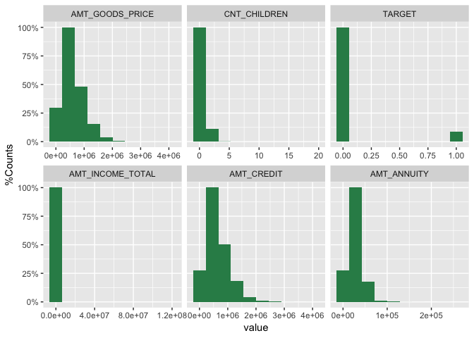

```r
ggplot(loans_tr.melt,aes(x=value,..ncount..),na.rm=TRUE)+
facet_wrap(~variable,scales='free_x') +
  geom_histogram(fill='seagreen4',bins=10)   +
  scale_y_continuous(labels = percent_format(),name='%Counts')
```

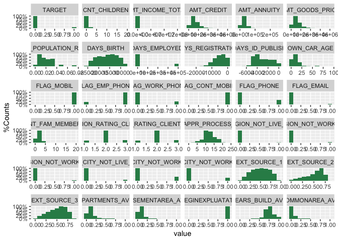

```r
loans_train.melt <- melt(loans_train[,sapply(loans_train,is.numeric)],id.vars=c("SK_ID_CURR"))

## Using Melt to histogram with 10 bins

ggplot(loans_train.melt,aes(x=value,..ncount..),na.rm=TRUE)+
#facet_wrap(~variable,scales='free_x') +
  facet_wrap_paginate(~variable,scales='free_x',ncol = 6, nrow = 6, page = 1) +
  geom_histogram(fill='seagreen4',bins=10)   +
  scale_y_continuous(labels = percent_format(),name='%Counts')
```

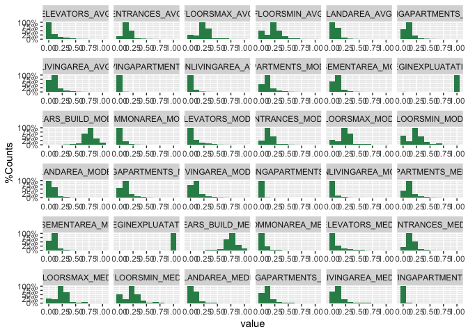

```r
ggplot(loans_train.melt,aes(x=value,..ncount..),na.rm=TRUE)+
#facet_wrap(~variable,scales='free_x') +
  facet_wrap_paginate(~variable,scales='free_x',ncol = 6, nrow = 6, page = 2) +
  geom_histogram(fill='seagreen4',bins=10)   +
  scale_y_continuous(labels = percent_format(),name='%Counts')
```

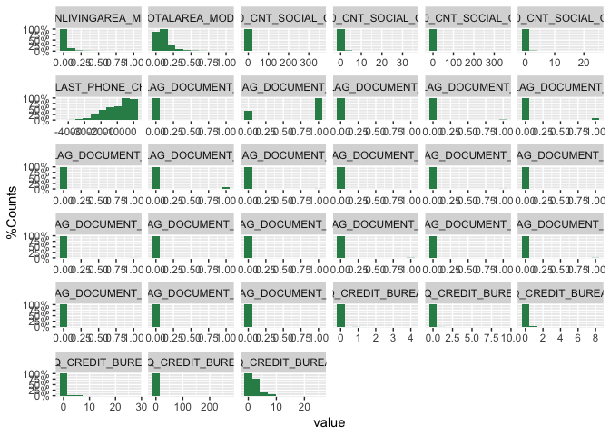

```r
ggplot(loans_train.melt,aes(x=value,..ncount..),na.rm=TRUE)+
#facet_wrap(~variable,scales='free_x') +
  facet_wrap_paginate(~variable,scales='free_x',ncol = 6, nrow = 6, page = 3) +
  geom_histogram(fill='seagreen4',bins=10)   +
  scale_y_continuous(labels = percent_format(),name='%Counts')
```

## 2.1 Create a Training and Test Samples

```r
set.seed(1)
train <- sample(1:nrow(loans_tr), nrow(loans_tr)*0.80)
test <- sample(1:nrow(loans_tr), nrow(loans_tr)*0.20)
```

## 2.2 Baselines Incidence Rate(BIR)

```r
bir.test.count <- data.frame(addmargins(xtabs(~ loans_tr[test,]$TARGET, data=loans_tr[test,])))
# add row/col summary (default is sum)
kable(bir.test.count, "html",caption ="Baseline Incidence Rate - Test Sample -Counts", booktabs = T,
      col.names = c("TARGET","Count"),
      format.args = list(big.mark=",")
      ) %>%
kable_styling(bootstrap_options = "striped","hover" ,full_width = F, position = "left")
```

Baseline Incidence Rate - Test Sample -Counts

| TARGET | Count |
| --- | --- |
| 0 | 56,587 |
| 1 | 4,915 |
| Sum | 61,502 |

```r
bir.test.prop <- data.frame(prop.table(xtabs(~ loans_tr[test,]$TARGET, data=loans_tr[test,])))
# show counts as proportions of total

kable(bir.test.prop, "html",caption ="Baseline Incidence Rate - Test Sample -Prop",booktabs = T,
      col.names = c("TARGET","Proportion")
      ) %>%
kable_styling(bootstrap_options = "striped","hover" ,full_width = F, position = "left")
```

Baseline Incidence Rate - Test Sample -Prop

| TARGET | Proportion |
| --- | --- |
| 0 | 0.9200839 |
| 1 | 0.0799161 |

```r
bir.train.count <- data.frame(addmargins(xtabs(~ loans_tr[train,]$TARGET, data=loans_tr[train,])))
# add row/col summary (default is sum)
kable(bir.train.count, "html",caption ="Baseline Incidence Rate - Train Sample -Counts", booktabs = T,
      col.names = c("TARGET","Count"),
       format.args = list(big.mark=",")) %>%
kable_styling(bootstrap_options = "striped","hover",full_width = F, position = "left")
```

Baseline Incidence Rate - Train Sample -Counts

| TARGET | Count |
| --- | --- |
| 0 | 226,156 |
| 1 | 19,852 |
| Sum | 246,008 |

```r
bir.train.prop <- data.frame(prop.table(xtabs(~ loans_tr[train,]$TARGET, data=loans_tr[train,])))
# show counts as proportions of total

kable(bir.train.prop, "html",caption ="Baseline Incidence Rate - Training Sample -Prop",booktabs = T,
      col.names = c("TARGET","Proportion")) %>%
kable_styling(bootstrap_options = "striped","hover",full_width = F, position = "left")
```

Baseline Incidence Rate - Training Sample -Prop

| TARGET | Proportion |
| --- | --- |
| 0 | 0.9193034 |
| 1 | 0.0806966 |

## 3.1 Train a logistic regression model:

```r
logit_model <- glm( TARGET~NAME_CONTRACT_TYPE+FLAG_OWN_CAR+FLAG_OWN_REALTY+AMT_CREDIT+
                    AMT_ANNUITY+AMT_GOODS_PRICE,
                    data = loans_tr[train,],
                    family = "binomial")

summary(logit_model)
```

```
##
## Call:
## glm(formula = TARGET ~ NAME_CONTRACT_TYPE + FLAG_OWN_CAR + FLAG_OWN_REALTY +
##     AMT_CREDIT + AMT_ANNUITY + AMT_GOODS_PRICE, family = "binomial",
##     data = loans_tr[train, ])
##
## Deviance Residuals:
##     Min       1Q   Median       3Q      Max
## -0.8968  -0.4447  -0.4103  -0.3479   3.0178
##
## Coefficients:
##                                     Estimate Std. Error  z value Pr(>|z|)
## (Intercept)                       -2.232e+00  2.029e-02 -110.012  < 2e-16
## NAME_CONTRACT_TYPERevolving loans -3.216e-01  3.126e-02  -10.288  < 2e-16
## FLAG_OWN_CARY                     -1.608e-01  1.628e-02   -9.881  < 2e-16
## FLAG_OWN_REALTYY                  -7.444e-02  1.606e-02   -4.634 3.58e-06
## AMT_CREDIT                         3.016e-06  1.203e-07   25.071  < 2e-16
## AMT_ANNUITY                        1.093e-05  8.331e-07   13.115  < 2e-16
## AMT_GOODS_PRICE                   -4.106e-06  1.388e-07  -29.584  < 2e-16
##
## (Intercept)                       ***
## NAME_CONTRACT_TYPERevolving loans ***
## FLAG_OWN_CARY                     ***
## FLAG_OWN_REALTYY                  ***
## AMT_CREDIT                        ***
## AMT_ANNUITY                       ***
## AMT_GOODS_PRICE                   ***
## ---
## Signif. codes:  0 '***' 0.001 '**' 0.01 '*' 0.05 '.' 0.1 ' ' 1
##
## (Dispersion parameter for binomial family taken to be 1)
##
##     Null deviance: 137864  on 245779  degrees of freedom
## Residual deviance: 136221  on 245773  degrees of freedom
##   (228 observations deleted due to missingness)
## AIC: 136235
##
## Number of Fisher Scoring iterations: 5
```

## 3.2 Score the logistic regression model on a Test dataset

```r
y_hat <- predict(logit_model, newdata = loans_tr[test,])
p_hat <- exp(y_hat)/(1 + exp(y_hat))  # convert the logodd output into probabilities
glm.pred <- rep(0, length(test))
glm.pred[p_hat > 0.0806] <- 1
```

## 3.3 Confusion Matrix - Logistic Regression

```r
glm.logit.cm <- caret::confusionMatrix(factor(glm.pred), factor(loans_tr[test,]$TARGET))
#names(glm.logit.cm) # [1] "positive" "table"    "overall"  "byClass"  "mode"     "dots"
glm.logit.cm
```

```
## Confusion Matrix and Statistics
##
##           Reference
## Prediction     0     1
##          0 25615  1734
##          1 30972  3181
##
##                Accuracy : 0.4682
##                  95% CI : (0.4643, 0.4722)
##     No Information Rate : 0.9201
##     P-Value [Acc > NIR] : 1
##
##                   Kappa : 0.0269
##  Mcnemar's Test P-Value : <2e-16
##
##             Sensitivity : 0.45267
##             Specificity : 0.64720
##          Pos Pred Value : 0.93660
##          Neg Pred Value : 0.09314
##              Prevalence : 0.92008
##          Detection Rate : 0.41649
##    Detection Prevalence : 0.44468
##       Balanced Accuracy : 0.54993
##
##        'Positive' Class : 0
##
```

```r
data.frame(glm.logit.cm$table) %>%
kable("html",caption ="Confusion Matrix - Logit",align='c',booktabs =T) %>%
kable_styling(bootstrap_options = "striped","hover",full_width = F, position = "left")
```

Confusion Matrix - Logit

| Prediction | Reference | Freq |
| --- | --- | --- |
| 0 | 0 | 25615 |
| 1 | 0 | 30972 |
| 0 | 1 | 1734 |
| 1 | 1 | 3181 |

```r
data.frame(glm.logit.cm$byClass) %>%
kable("html",caption ="Confusion Matrix - Sensitivity/Specificity",align='c',booktabs =T) %>%
kable_styling(bootstrap_options = "striped","hover",full_width = F, position = "left")
```

Confusion Matrix - Sensitivity/Specificity

|  | glm.logit.cm.byClass |
| --- | --- |
| Sensitivity | 0.4526658 |
| Specificity | 0.6472024 |
| Pos Pred Value | 0.9365973 |
| Neg Pred Value | 0.0931397 |
| Precision | 0.9365973 |
| Recall | 0.4526658 |
| F1 | 0.6103460 |
| Prevalence | 0.9200839 |
| Detection Rate | 0.4164905 |
| Detection Prevalence | 0.4446847 |
| Balanced Accuracy | 0.5499341 |

## 3.4 Receiver Operating Characteristic Curve / Area under the Curve - Logistic Regression

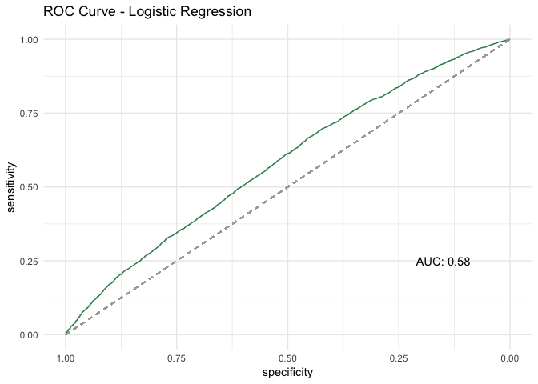

```r
logit.ROC <- roc(response=loans_tr[test,]$TARGET,
                 predictor=p_hat,
                 levels=rev(levels(factor(loans_tr[test,]$TARGET))))
# names(logit.ROC)
# [1] "percent"            "sensitivities"      "specificities"      "thresholds"
#  [5] "direction"          "cases"              "controls"           "fun.sesp"
#  [9] "auc"                "call"               "original.predictor" "original.response"
# [13] "predictor"          "response"           "levels"
auc.logit <- format(logit.ROC$auc,digits=2)


g <- ggroc(logit.ROC,colour="seagreen4",linetype=1)
g + theme_minimal()+ annotate("text", x=0.15, y=0.25, label=paste('AUC:',auc.logit)) +
  ggtitle("ROC Curve - Logistic Regression")+
  geom_segment(aes(x = 1, xend = 0, y = 0, yend = 1),
                 color="darkgrey", linetype="dashed")
```

## Gradient Boosting Model: Introduction

The family of boosting methods is based on an additive strategy of ensemble formation. The main idea of boosting is to add new models to the ensemble sequentially. At each particular iteration, a decision tree is trained with respect to the error of the whole ensemble learnt so far.

Steps:

1. Fit a decision tree to the data: F1(x) = y,
2. We then fit the next decision tree to the residuals of the previous: h1(x) = y − F1(x),
3. Add this new tree to our algorithm: F2(x) = F1(x) + h1(x),
4. Continue this process until some mechanism (i.e. cross validation) tells us to stop.

Advantages:

1. Often provides predictive accuracy that cannot be beat, Win’s most kaagle.com competitions with respect to predictive accuracy.
2. Lots of flexibility - can optimize on different loss functions and provides several hyper-parameter tuning options that make the function fit very flexible.
3. No data pre-processing required - often works great with categorical and numerical values as is.
4. Handles missing data - imputation not required

Disadvantages:

1. GBMs will continue improving to minimize all errors. This can overemphasize outliers and cause over fitting. Must use cross-validation to neutralize.
2. Computationally expensive - GBMs often require many trees (>1000) which can be time and memory exhaustive.
3. The high flexibility results in many parameters that interact and influence heavily the behavior of the approach (number of iterations, tree depth, regularization parameters, etc.). This requires a large grid search during tuning.
4. Less interpretable although this is easily addressed with various tools (variable importance, partial dependence plots, LIME, etc.).

Source: http://uc-r.github.io/gbm_regression

## 4.1 Simulation for Finding Optimal shrinkage factor/learning Rate

```r
# set.seed(103)
# pows = seq(-10, -0.2, by = 0.1)
# lambdas = 10^pows
# length.lambdas = length(lambdas)
# train.errors = rep(NA, length.lambdas)
# test.errors = rep(NA, length.lambdas)
# for (i in 1:length.lambdas) {
#     boost.prelim = gbm(TARGET ~ ., data = loans_tr[train,], n.trees = 1000,  shrinkage = lambdas[i])
#     train.pred = predict(boost.prelim, loans_tr[train,], n.trees = 1000)
#     test.pred = predict(boost.prelim, loans_tr[test,], n.trees = 1000)
#     train.errors[i] = mean((loans_tr[train,]$TARGET - train.pred)^2)
#     test.errors[i] = mean((loans_tr[test,]$TARGET - test.pred)^2)
# }
#

# print("Shrinkage by Train MSE")
# train.errors
# plot(lambdas, train.errors, type = "b", xlab = "Shrinkage", ylab = "Train MSE",
#     col = "blue", pch = 20, xlim=c(10^-7,0.004), ylim=c(6,6.8))
# axis(side=1,at=c(seq(10^-6, 0.004, by = 10^-0.001)),
#      labels=round(c(seq(10^-6, 0.004, by = 10^-0.001)),digits=6),
#      las=2)
# title(cex.lab=0.6)
# min(test.errors)
#
#
# lambdas
# test.errors
# min(test.errors)
# plot(lambdas, test.errors, type = "b", xlab = "Shrinkage", ylab = "Test MSE",
#     col = "red", pch = 20, xlim=c(10^-7,0.004), ylim=c(6.2,6.5))
# axis(side=1,at=c(seq(10^-6, 0.004, by = 10^-0.001))
#      #labels=round(c(seq(10^-6, 0.004, by = 10^-0.001)),digits=5),
#      )
# lambdas[which.min(test.errors)]
#
```

## 4.2 Training a Gradient Boosting Model

```r
boost.loans <-gbm(TARGET ~ . -SK_ID_CURR,
                  data = loans_tr[train,],
                  n.trees = 1000,
                  shrinkage = 0.01,
                  distribution = "bernoulli",
                  verbose=FALSE)

# names(boost.loans)
# [1] "initF"             "fit"               "train.error"       "valid.error"
#  [5] "oobag.improve"     "trees"             "c.splits"          "bag.fraction"
#  [9] "distribution"      "interaction.depth" "n.minobsinnode"    "num.classes"
# [13] "n.trees"           "nTrain"            "train.fraction"    "response.name"
# [17] "shrinkage"         "var.levels"        "var.monotone"      "var.names"
# [21] "var.type"          "verbose"           "data"              "Terms"
# [25] "cv.folds"          "call"              "m"

varimp <- data.frame(summary(boost.loans ) )
```

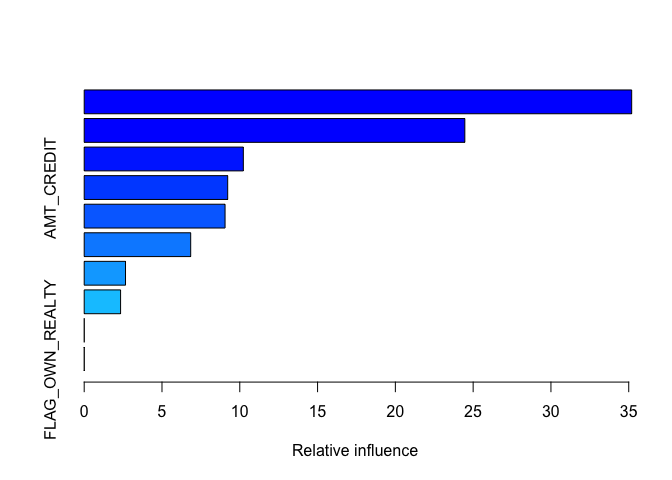

```r
str(varimp)
```

```
## 'data.frame':    10 obs. of  2 variables:
##  $ var    : Factor w/ 10 levels "AMT_ANNUITY",..: 3 6 1 2 7 9 4 5 10 8
##  $ rel.inf: num  35.19 24.47 10.23 9.22 9.05 ...
```

```r
printvi <- varimp %>%
  arrange(desc(rel.inf)) %>%
kable("html",caption ="Variable - Relative Influence",align='c',booktabs =T) %>%
kable_styling(bootstrap_options = "striped","hover",full_width = F, position = "left")

printvi
```

Variable - Relative Influence

| var | rel.inf |
| --- | --- |
| AMT_GOODS_PRICE | 35.189680 |
| CODE_GENDER | 24.465440 |
| AMT_ANNUITY | 10.228470 |
| AMT_CREDIT | 9.223400 |
| FLAG_OWN_CAR | 9.053912 |
| NAME_CONTRACT_TYPE | 6.845110 |
| AMT_INCOME_TOTAL | 2.655213 |
| CNT_CHILDREN | 2.338774 |
| NAME_TYPE_SUITE | 0.000000 |
| FLAG_OWN_REALTY | 0.000000 |

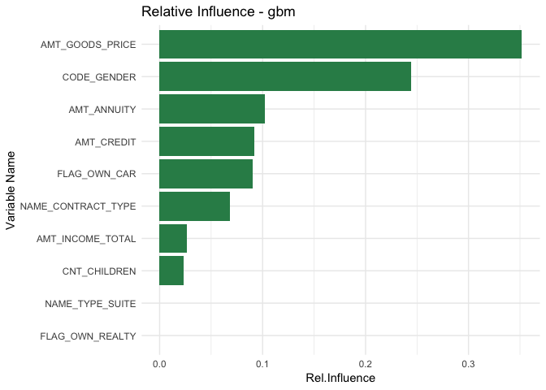

```r
varimp %>%
  arrange(desc(rel.inf)) %>%
 ggplot() +
  geom_bar(mapping = aes(x = reorder(var,rel.inf), y = ..prop.., weight = rel.inf, group=1),
           fill="seagreen4") +
  theme_minimal()+
  coord_flip()+
  labs(y="Rel.Influence",x="Variable Name",title="Relative Influence - gbm")
```

## 4.3 Score the Gradient Boosting Model on a Test dataset

```r
boost.prob = predict(boost.loans, loans_tr[test,], n.trees = 1000, type = "response")
boost.pred <- rep(0, length(test))
boost.pred[boost.prob > 0.0806] <- 1
```

## 4.4 Confusion Matrix - Gradient Boosting

```
## Confusion Matrix and Statistics
##
##           Reference
## Prediction     0     1
##          0 33100  2009
##          1 23487  2906
##
##                Accuracy : 0.5854
##                  95% CI : (0.5815, 0.5893)
##     No Information Rate : 0.9201
##     P-Value [Acc > NIR] : 1
##
##                   Kappa : 0.0588
##  Mcnemar's Test P-Value : <2e-16
##
##             Sensitivity : 0.5849
##             Specificity : 0.5913
##          Pos Pred Value : 0.9428
##          Neg Pred Value : 0.1101
##              Prevalence : 0.9201
##          Detection Rate : 0.5382
##    Detection Prevalence : 0.5709
##       Balanced Accuracy : 0.5881
##
##        'Positive' Class : 0
##
```

Confusion Matrix - GBM

| Prediction | Reference | Freq |
| --- | --- | --- |
| 0 | 0 | 33100 |
| 1 | 0 | 23487 |
| 0 | 1 | 2009 |
| 1 | 1 | 2906 |

Confusion Matrix - Sensitivity/Specificity

|  | gbm.cm.byClass |
| --- | --- |
| Sensitivity | 0.5849400 |
| Specificity | 0.5912513 |
| Pos Pred Value | 0.9427782 |
| Neg Pred Value | 0.1101050 |
| Precision | 0.9427782 |
| Recall | 0.5849400 |
| F1 | 0.7219508 |
| Prevalence | 0.9200839 |
| Detection Rate | 0.5381939 |
| Detection Prevalence | 0.5708595 |
| Balanced Accuracy | 0.5880956 |

## 4.5 Receiver Operating Characteristic Curve / Area under the Curve - Gradient Boosting

[figure not shown]

# 4.6 Compartive Analysis - Logistic Regression vs Gradient Boosting -ROC Curves /AUC:

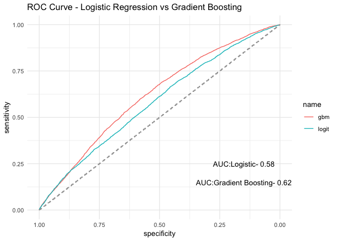

```r
g3 <- ggroc(list(logit=logit.ROC, gbm=gbm.ROC))
g3 + theme_minimal()+ annotate("text", x=0.15, y=0.25, label=paste('AUC:Logistic-',auc.logit)) +
  annotate("text", x=0.15, y=0.15, label=paste('AUC:Gradient Boosting-',auc.gbm))+
  ggtitle("ROC Curve - Logistic Regression vs Gradient Boosting")+
  geom_segment(aes(x = 1, xend = 0, y = 0, yend = 1),
                 color="darkgrey", linetype="dashed")
```

# Appendix